# PEC1_2526S1_Sol

Equipo docente SAD

2025-09-24

## Software para el análisis de datos (SAD).

## Prueba de evaluación continua (PEC1). Propuesta de solución.

El objetivo de esta PEC1 es la introducción al lenguaje R e iniciación al análisis y tratamiento estadístico de un conjunto de datos. A lo largo de la práctica se utilizarán diferentes conjuntos de datos, algunos provenientes de fuentes externas y otros propios del entorno RStudio. En particular, será necesario acceder a los siguientes conjuntos de datos:

```
1. El sitio web https://www.kaggle.com/ dispone de conjuntos de datos (datasets) de libre acceso y descarga, previa validación del usuario. En esta PEC1 trabajaremos con un conjunto de datos que tratan sobre los factores que pueden contribuir a la calvicie de las personas: https://www.kaggle.com/datasets/amitvkulkarni/hair-health.
2. Conjunto de datos BOD del paquete datasets de Rstudio que trabaja datos sobre la demanda bioquímica de oxígeno en función del tiempo, en una evaluación de la calidad del agua.
```

### Sección 1. Importación, exportación y gestión de datos (2 puntos)

El objetivo de esta sección es conocer la sintaxis en R para importar y exportar diferentes tipos de archivos de datos y cómo visualizarlos desde Rstudio, así como acceder a conjuntos de datos de diferentes fuentes y entornos. Esta primera parte corresponde al paso inicial de un estudio de análisis de datos, iniciando por el trabajo de preparación del propio conjunto de datos.

#### (1 punto) Ejercicio 1

Resolved las siguientes cuestiones, mostrando las instrucciones de código utilizadas, así como el resultado de la ejecución de dicho código.

1.1. A partir de la URL anterior, importad los datos del archivo Predict_Hair_Fall.csv correspondiente a los datos de factores de caída del cabello. Guardad estos datos en un data frame llamado hair_fall y mostrad los primeros registros del conjunto de datos.

```r
## Importamos el archivo y mostramos los primeros registros
HairFallH=read.csv("C:/Users/Esther/Desktop/SAD_PEC1_2526S1/Predict_Hair_Fall.csv", header=TRUE,sep=",")
head(HairFallH, n=10)
```

```
##        Id Genetics Hormonal.Changes Medical.Conditions Medications...Treatments
## 1  133992      Yes               No            No Data                  No Data
## 2  148393       No               No             Eczema              Antibiotics
## 3  155074       No               No         Dermatosis         Antifungal Cream
## 4  118261      Yes              Yes           Ringworm              Antibiotics
## 5  111915       No               No          Psoriasis                 Accutane
## 6  139661      Yes               No          Psoriasis              Antibiotics
## 7  169255      Yes              Yes            No Data                  No Data
## 8  112032      Yes               No         Dermatosis             Chemotherapy
## 9  140785      Yes               No             Eczema                 Steroids
## 10 187999       No              Yes           Ringworm                  Rogaine
##    Nutritional.Deficiencies   Stress Age Poor.Hair.Care.Habits
## 1      Magnesium deficiency Moderate  19                   Yes
## 2      Magnesium deficiency     High  43                   Yes
## 3        Protein deficiency Moderate  26                   Yes
```

[output cut: 18 more lines]

Podemos comprobar cómo la distribución contiene valores ‘No data’.

```r
tail(HairFallH,n=10)
```

```
##         Id Genetics Hormonal.Changes    Medical.Conditions
## 990 144786       No               No              Ringworm
## 991 127532      Yes               No      Alopecia Areata
## 992 131739       No              Yes      Thyroid Problems
## 993 181854      Yes              Yes            Dermatosis
## 994 196218       No              Yes       Scalp Infection
## 995 184367      Yes               No Seborrheic Dermatitis
## 996 164777      Yes              Yes               No Data
## 997 143273       No              Yes Androgenetic Alopecia
## 998 169123       No              Yes            Dermatitis
## 999 127183      Yes              Yes             Psoriasis
##      Medications...Treatments Nutritional.Deficiencies   Stress Age
## 990                   Rogaine      Selenium deficiency Moderate  45
## 991          Antidepressants           Zinc Deficiency      Low  42
## 992          Antidepressants           Zinc Deficiency     High  33
```

[output cut: 18 more lines]

1.2. A partir del conjunto datos definido, HairFall, describid las características del conjunto de datos como el nombre de las variables, el tipo de datos, el tamaño de la muestra, y prospección de valores nulos. Además, valorad qué tipo de estudio, gráficos, etc… podréis realizar en función del tipo de variables. Nota.- Recordad que, si existen valores faltantes, se recomienda eliminar las filas implicadas.

Veamos a continuación los campos que forman el conjunto de datos:

```
##  [1] "Id"                       "Genetics"
##  [3] "Hormonal.Changes"         "Medical.Conditions"
##  [5] "Medications...Treatments" "Nutritional.Deficiencies"
##  [7] "Stress"                   "Age"
##  [9] "Poor.Hair.Care.Habits"    "Environmental.Factors"
## [11] "Smoking"                  "Weight.Loss"
## [13] "Hair.Loss"
```

Veamos ahora el tipo de variables:

```r
str(HairFallH)
```

```
## 'data.frame':    999 obs. of  13 variables:
##  $ Id                      : int  133992 148393 155074 118261 111915 139661 169255 112032 140785 187999 ...
##  $ Genetics                : chr  "Yes" "No" "No" "Yes" ...
##  $ Hormonal.Changes        : chr  "No" "No" "No" "Yes" ...
##  $ Medical.Conditions      : chr  "No Data" "Eczema" "Dermatosis" "Ringworm" ...
##  $ Medications...Treatments: chr  "No Data" "Antibiotics" "Antifungal Cream" "Antibiotics" ...
##  $ Nutritional.Deficiencies: chr  "Magnesium deficiency" "Magnesium deficiency" "Protein deficiency" "Biotin Deficiency " ...
##  $ Stress                  : chr  "Moderate" "High" "Moderate" "Moderate" ...
##  $ Age                     : int  19 43 26 46 30 37 40 35 19 49 ...
##  $ Poor.Hair.Care.Habits   : chr  "Yes" "Yes" "Yes" "Yes" ...
##  $ Environmental.Factors   : chr  "Yes" "Yes" "Yes" "Yes" ...
##  $ Smoking                 : chr  "No" "No" "No" "No" ...
##  $ Weight.Loss             : chr  "No" "No" "Yes" "No" ...
##  $ Hair.Loss               : int  0 0 0 0 1 1 1 0 1 0 ...
```

```r
dim(HairFallH)
```

```
## [1] 999  13
```

Tenemos 999 registros y 13 columnas.

```r
table(is.na(HairFallH))
```

```
##
## FALSE
## 12987
```

El anterior valor nos indica que no hay ninguna celda sin valor (999 registros x 13 columnas). Ahora bien, si revisamos los valores de cada variable, sí detectamos que Medical.Conditions i Medications.Treatments contienen valores ‘No data’. En este caso, procederíamos a transformar los valores ‘No data’ a ‘NA’:

```r
HairFallH[HairFallH == "No Data"] <- NA
head(HairFallH)
```

```
##       Id Genetics Hormonal.Changes Medical.Conditions Medications...Treatments
## 1 133992      Yes               No               <NA>                     <NA>
## 2 148393       No               No             Eczema              Antibiotics
## 3 155074       No               No         Dermatosis         Antifungal Cream
## 4 118261      Yes              Yes           Ringworm              Antibiotics
## 5 111915       No               No          Psoriasis                 Accutane
## 6 139661      Yes               No          Psoriasis              Antibiotics
##   Nutritional.Deficiencies   Stress Age Poor.Hair.Care.Habits
## 1     Magnesium deficiency Moderate  19                   Yes
## 2     Magnesium deficiency     High  43                   Yes
## 3       Protein deficiency Moderate  26                   Yes
## 4       Biotin Deficiency  Moderate  46                   Yes
## 5          Iron deficiency Moderate  30                    No
## 6     Magnesium deficiency      Low  37                    No
##   Environmental.Factors Smoking Weight.Loss Hair.Loss
## 1                   Yes      No          No         0
## 2                   Yes      No          No         0
## 3                   Yes      No         Yes         0
## 4                   Yes      No          No         0
## 5                   Yes     Yes          No         1
## 6                   Yes      No         Yes         1
```

Posteriormente, evaluamos cuantos valores ‘NA’ tenemos en la distribución:

```r
sum(is.na(HairFallH))
```

```
## [1] 192
```

En este caso, se propone eliminar todos aquellos registros que contengan algun valor faltante:

```r
HairFall <- na.omit(HairFallH)
```

Podemos comprobar como, ahora, ya no disponemos de datos faltantes:

```r
table(is.na(HairFall))
```

```
##
## FALSE
## 10517
```

```r
dim(HairFall)
```

```
## [1] 809  13
```

Hemos reducido 190 registros del conjunto de datos inicial.

Los tipos de gráficos que podríamos realizar son, por ejemplo, histogramas para visualizar la distribución por edades o un boxplot entre las variables Hair.Loss y Age para ver si la caïda de cabello es más frecuente en ciertas edades. También podríamos mostrar diagramas de barras por categorías de variables.

#### (1 punto) Ejercicio 2. Exploración del entorno RStudio y paquetes asociados.

En este ejercicio se trabajará con conjuntos de datos de paquetes instalados en el propio RStudio. A partir del conjunto de datos BOD del paquete datasets de Rstudio, se pide:

2.1. En base a las cuestiones trabajadas al ejercicio anterior, explicad qué información contiene el conjunto de datos, así como las características más relevantes de la estructura de este conjunto de datos. Sugerid y justificad alguna acción de prospección y preparación de los datos (transformación o categorización de alguna de las variables, eliminación de algún tipo de datos,…), así como también qué tipo de estudios y gráficos podríamos realizar a partir del tipo de variables que conforman el conjunto de datos.

```r
library(datasets)
data("BOD")
bod<-BOD
bod
```

```
##   Time demand
## 1    1    8.3
## 2    2   10.3
## 3    3   19.0
## 4    4   16.0
## 5    5   15.6
## 6    7   19.8
```

Según la información que aparece al entorno RStudio:

*Biochemical Oxygen Demand* Description The BOD data frame has 6 rows and 2 columns giving the biochemical oxygen demand versus time in an evaluation of water quality.

*Usage* BOD Format This data frame contains the following columns:

**Time** A numeric vector giving the time of the measurement (days).

**demand** A numeric vector giving the biochemical oxygen demand (mg/l).

Veamos las características de la estructura del conjunto de datos:

```r
names(bod)
```

```
## [1] "Time"   "demand"
```

Es una estructura de datos con sólo dos variables.

```r
str(bod)
```

```
## 'data.frame':    6 obs. of  2 variables:
##  $ Time  : num  1 2 3 4 5 7
##  $ demand: num  8.3 10.3 19 16 15.6 19.8
##  - attr(*, "reference")= chr "A1.4, p. 270"
```

Dichas variables son de tipo numérico.

```r
dim(bod)
```

```
## [1] 6 2
```

Como hemos comprobado, existen 6 registros y dos columnas (variables).

```r
table(is.na(bod))
```

```
##
## FALSE
##    12
```

No existen valores nulos.

De este conjunto de datos, cabe destacar que existen muy pocos registros y columnas para realizar estudios exhaustivos. Como hemos dicho, las variables son de tipo numérico y uno de los estudios principales que podria realizarse sería ver cómo el tiempo influye en la demanda de oxígeno. Podrían representarse gráficos de tipo boxplot o histogramas individuales para cada columna y, también, un diagrama de dispersión para ver si hay relación entre el tiempo y la demanda. En cuanto a estudios, puede realizarse un análisis descriptivo sobre las dos variables **Time** y **demand**, así como una análisis de correlación para medir la relación entre ambas variables.

2.2. Exportad el data frame BOD a un archivo en formato *.csv especificando la ubicación del archivo.

```r
write.table(bod,"/Users/Esther/Desktop/SAD_PEC1_2526S1/bod.csv",sep="") ##Exportar a formato csv
```

Ha quedado creado el archivo en la carpeta correspondiente.

### Sección 2. Análisis básico del conjunto de datos (3,5 puntos)

#### Ejercicio 3.

Considerando el data frame resultante del Ejercicio 1, anteriormente definido, resolved las siguientes cuestiones:

(0.5 puntos) 3.1. Calculad la proporción de personas según el nivel de estrés, agrupadas por el tipo de deficiencia nutricional. Comentad los resultados.

```r
table(HairFall$Nutritional.Deficiencies, HairFall$Stress)
```

```
##
##                        High Low Moderate
##   Biotin Deficiency      22  35       32
##   Iron deficiency        16  22       30
##   Magnesium deficiency   15  23       33
##   Omega-3 fatty acids    22  32       28
##   Protein deficiency     28  16       35
##   Selenium deficiency    14  17       37
##   Vitamin A Deficiency   29  33       29
##   Vitamin D Deficiency   30  22       42
##   Vitamin E deficiency   24  27       20
##   Zinc Deficiency        27  32       37
```

```r
prop.table(table(HairFall$Nutritional.Deficiencies, HairFall$Stress))
```

```
##
##                              High        Low   Moderate
##   Biotin Deficiency    0.02719407 0.04326329 0.03955501
##   Iron deficiency      0.01977750 0.02719407 0.03708282
##   Magnesium deficiency 0.01854141 0.02843016 0.04079110
##   Omega-3 fatty acids  0.02719407 0.03955501 0.03461063
##   Protein deficiency   0.03461063 0.01977750 0.04326329
##   Selenium deficiency  0.01730532 0.02101360 0.04573548
##   Vitamin A Deficiency 0.03584672 0.04079110 0.03584672
##   Vitamin D Deficiency 0.03708282 0.02719407 0.05191595
##   Vitamin E deficiency 0.02966625 0.03337454 0.02472188
##   Zinc Deficiency      0.03337454 0.03955501 0.04573548
```

Del anterior resultado, podríamos deducir que hay una asociación leve entre deficiencias nutricionales y niveles de estrés.

Algunas deficiencias específicas (como proteínas, vitamina A, D y zinc) destacan en niveles altos de estrés, lo que podría sugerir una relación entre estrés elevado y mayor requerimiento de ciertos nutrientes.

En general, parece que las deficiencias no se concentran en un solo nivel de estrés, lo que podría sugerir que existen otros factores que podrían influir.

(0.5 puntos) 3.2. Mostrad la relación entre el estrés (Stress) y la caída de cabello (Hair Loss=1). Mostrad un gráfico que compare dichas proporciones.

```r
# Filtramos los datos para obtener solo aquellos donde Hair Loss es 1
HairFall_loss <- subset(HairFall, Hair.Loss == 1)
table(HairFall$Stress)
```

```
##
##     High      Low Moderate
##      227      259      323
```

```r
prop.table(table(HairFall_loss$Stress))
```

```
##
##      High       Low  Moderate
## 0.2745098 0.3161765 0.4093137
```

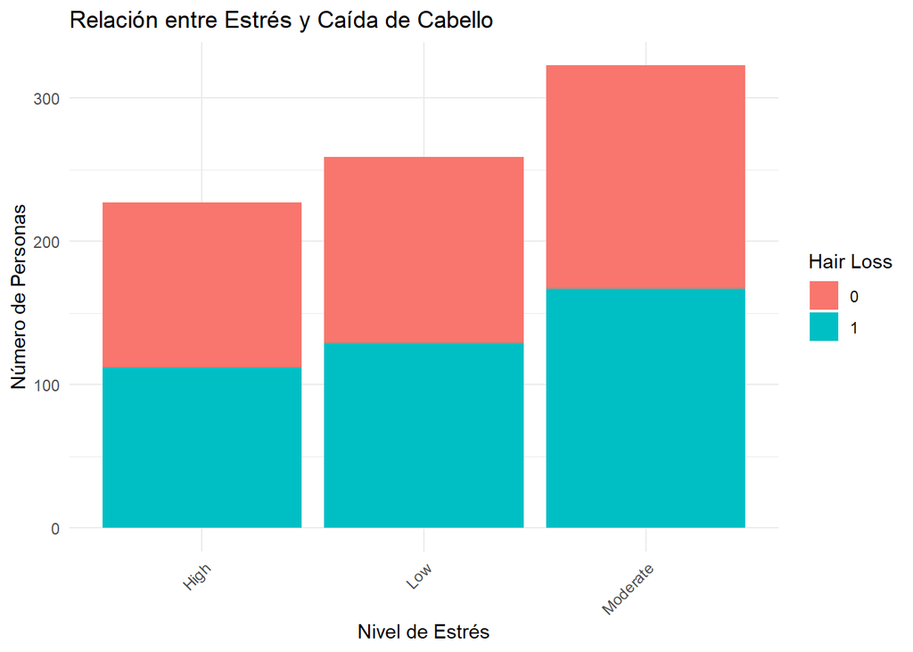

```r
# Cargamos ggplot2
library(ggplot2)
# Gráfico de barras
ggplot(HairFall, aes(x = Stress, fill = as.factor(Hair.Loss))) +
  geom_bar(position = "stack") +
  labs(title = "Relación entre Estrés y Caída de Cabello",
       x = "Nivel de Estrés",
       y = "Número de Personas",
       fill = "Hair Loss") +
  theme_minimal() +
  theme(axis.text.x = element_text(angle = 45, hjust = 1))
```

Del gráfico anterior, podríamos valorar que la caída del cabello se observa con mayor frecuencia en personas con estrés moderado (41%), seguida de estrés bajo (32%) y estrés alto (27.5%). En esta distribución, la caída del cabello es más frecuente entre personas con estrés moderado.

(0.5 puntos) 3.3. Evaluad la caída de cabello (Hair.Loss=1) con deficiencias de nutrición específicas (Nutritional.Deficiencies), contando el número de personas por cada tipo de deficiencia nutricional.

```r
# Filtramos por deficiencias nutricionales
HairFall_nutritional_deficiencies <- subset(HairFall, Hair.Loss == 1)

# Contamos el núm de personas de cada grupo
Total <- sort(table( HairFall_nutritional_deficiencies$Nutritional.Deficiencies), decreasing = TRUE)

Total
```

```
##
## Vitamin A Deficiency Vitamin D Deficiency      Zinc Deficiency
##                   47                   45                   45
##   Biotin Deficiency    Protein deficiency Magnesium deficiency
##                   43                   43                   42
##  Omega-3 fatty acids      Iron deficiency Vitamin E deficiency
##                   38                   36                   35
##  Selenium deficiency
##                   34
```

Los anteriores datos parecen indicar que la Vitamina A es la deficiencia más común entre los pacientes de la muestra.

(0.5 puntos) 3.4. Mostrad en una tabla el número de personas con caída de cabello, agrupadas por nivel de estrés, que sean fumadoras y cuya edad sea inferior a la media de la distribución.

```r
HairFall_smoking_age <- subset(HairFall, Hair.Loss == 1 & HairFall$Age < mean(Age, na.rm = TRUE) & Smoking == "Yes")

table(HairFall_smoking_age$Stress)
```

```
##
##     High      Low Moderate
##       26       32       48
```

De los anteriores resultados, se deduce que con los criterios definidos el nivel de estrés más representado es el Moderado.

(0.5 puntos) 3.5. Mostrad las personas con edad mínima que presentan caída de cabello, fuman, tienen el nivel de estres alto y tienen algun tratamiento médico asociado. ¿Qué deficiencia nutricional presentan?

```r
# Creamos filtro
HairFall_min_age <- subset(HairFall, Hair.Loss== 1 & Smoking == "Yes" & Stress=="High" & Nutritional.Deficiencies!="No Data")
min_age <- min(HairFall_min_age$Age, na.rm = TRUE)

HairFall_min_age_nutritional <- subset(HairFall_min_age,HairFall_min_age$Age == min_age,  select = c("Age", "Nutritional.Deficiencies"))

#Resultado
HairFall_min_age_nutritional
```

```
##     Age Nutritional.Deficiencies
## 112  24     Vitamin A Deficiency
## 461  24     Vitamin E deficiency
## 501  24     Vitamin A Deficiency
```

A partir de los criterios del enunciado, la deficiencia nutricional que presentan es la de Vitamina A y E.

(1 punto) 3.6. En base a las cuestiones realizadas anteriormente, añadid una nueva cuestión que incluya una representación gráfica. (Respuesta abierta)

### Sección 3: Estadística descriptiva, normalidad y gráficos (4 puntos)

El objetivo de este apartado trabajar los conceptos de estadística descriptiva y representación de gráficos. Para ello, seguiremos trabajando con el conjunto de datos HairFall.

#### Ejercicio 4.

(0.5 puntos) 4.1. A partir del conjunto de datos citado, mostrad los estadísticos descriptivos más relevantes y comentad los resultados, teniendo en cuenta el tipo de variables del conjunto de datos.

```r
# Estadísticos descriptivos HairFall
summary(HairFall)
```

```
##        Id           Genetics         Hormonal.Changes   Medical.Conditions
##  Min.   :110003   Length:809         Length:809         Length:809
##  1st Qu.:131739   Class :character   Class :character   Class :character
##  Median :152667   Mode  :character   Mode  :character   Mode  :character
##  Mean   :153247
##  3rd Qu.:175168
##  Max.   :199949
##  Medications...Treatments Nutritional.Deficiencies    Stress
##  Length:809               Length:809               Length:809
##  Class :character         Class :character         Class :character
##  Mode  :character         Mode  :character         Mode  :character
##
##
##
##       Age        Poor.Hair.Care.Habits Environmental.Factors   Smoking
##  Min.   :18.00   Length:809            Length:809            Length:809
##  1st Qu.:28.00   Class :character      Class :character      Class :character
##  Median :35.00   Mode  :character      Mode  :character      Mode  :character
##  Mean   :34.76
##  3rd Qu.:42.00
##  Max.   :50.00
##  Weight.Loss          Hair.Loss
##  Length:809         Min.   :0.0000
##  Class :character   1st Qu.:0.0000
##  Mode  :character   Median :1.0000
##                     Mean   :0.5043
##                     3rd Qu.:1.0000
##                     Max.   :1.0000
```

Podemos comprobar que la mayoría de variables son de tipo caracter y, por lo tanto, este tipo de análisis sólo tendría sentido en variables como *Age*. Respecto a esta variable, podemos ver cómo el rango de personas del estudio tienen entre 18 y 50 años, con una media de edad de 34 años.

(1 punto) 4.2. Realizad un boxplot que relacione la edad (Age) con la caída de cabello (Hair.Loss), qué podéis concluir?

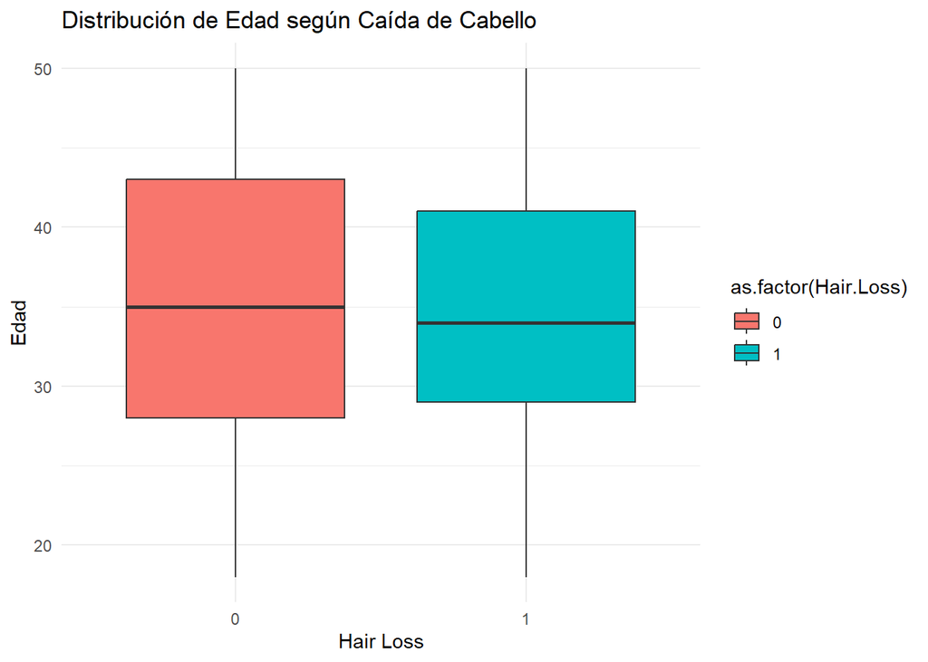

```r
# Cargamos el paquete ggplot2
library(ggplot2)

ggplot(HairFall, aes(x = as.factor(Hair.Loss), y = Age, fill = as.factor(Hair.Loss))) +
  geom_boxplot() +
  labs(title = "Distribución de Edad según Caída de Cabello",
       x = "Hair Loss",
       y = "Edad") +
  theme_minimal()
```

Podemos valorar que la distribución de edades es muy parecida en ambos grupos (Hair.Loss = 0 y Hair.Loss = 1), la medianas estan casi al mismo nivel y parece que no hay grandes diferencias en la dispersión de la edad. Sería útil conocer el criterio de recogida de datos de la muestra del conjunto de dato, ya que según éstos no parece que la edad sea un factor determinante en la caída de cabello.

(1 punto) 4.3. Realizad una tabla de frecuencias que relacione las condiciones médicas (Medical.Conditions) de las personas con el factor de caída del cabello (Hair.Loss) y realizad gráfico tipo ‘Mapa de calor’ para visualizar cuales son los factores más relevantes.

Inicialmente, construimos una tabla de frecuencias con los criterios especificados.

```r
library(ggplot2)

# Tabla de frecuencias
hair_medical_loss <- table(Medical.Conditions=HairFall$Medical.Conditions, Hair.Loss=HairFall$Hair.Loss)
hair_medical_loss
```

```
##                        Hair.Loss
## Medical.Conditions       0  1
##   Alopecia Areata       41 57
##   Androgenetic Alopecia 40 49
##   Dermatitis            43 39
##   Dermatosis            41 39
##   Eczema                34 31
##   Psoriasis             45 46
##   Ringworm              32 28
##   Scalp Infection       38 36
##   Seborrheic Dermatitis 35 44
##   Thyroid Problems      52 39
```

A continuación, representamos el mapa de calor:

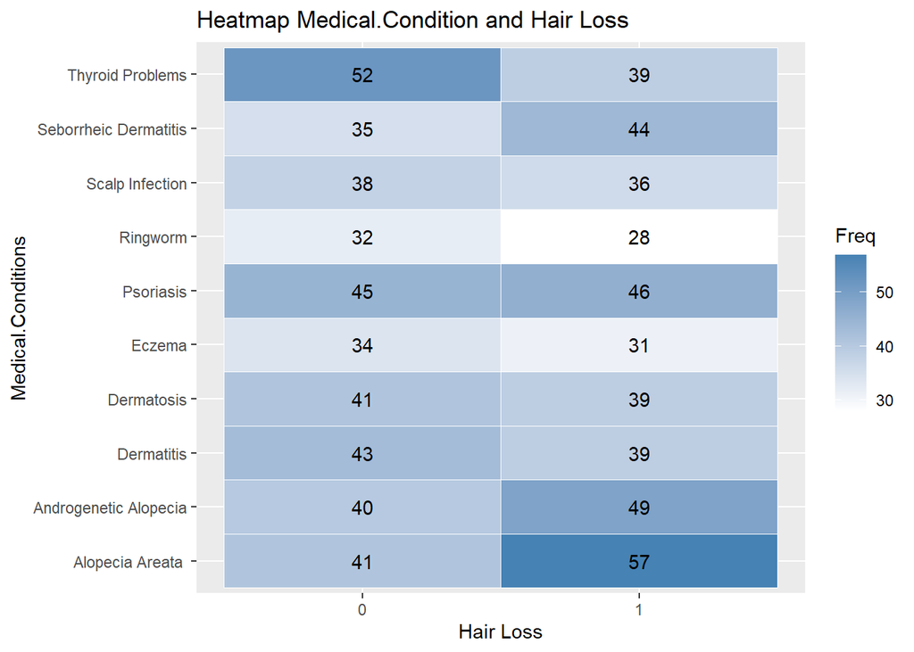

```r
# Convertimos en data.frame para aplicar ggplot
df_hair_medical_loss <- as.data.frame(hair_medical_loss)

# Dibujamos mapa de calor
ggplot(df_hair_medical_loss, aes(x = Hair.Loss, y = Medical.Conditions, fill = Freq)) +
 # ggplot(df_hair_medical_loss, aes(x = HairFall, y = Medical.Conditions, fill = Freq)) +
  geom_tile(color = "white") +
  geom_text(aes(label = Freq), color = "black") +
  scale_fill_gradient(low = "white", high = "steelblue") +
  labs(title = "Heatmap Medical.Condition and Hair Loss",
       x = "Hair Loss", y = "Medical.Conditions")
```

Parece ser que la Androgenetic Alopecia y la Alopecia Areata, como parece lógico, son las condiciones médicas asociadas a la caida de cabello de forma más común.

(1 punto) 4.4. Representad un histograma de la edad de las personas con caïda de cabello. A partir de aquí, y teniendo en cuenta los conceptos de normalidad trabajados al LAB1, representad la curva de densidad normal y evaluad la normalidad de la distribución y comentad los resultados.

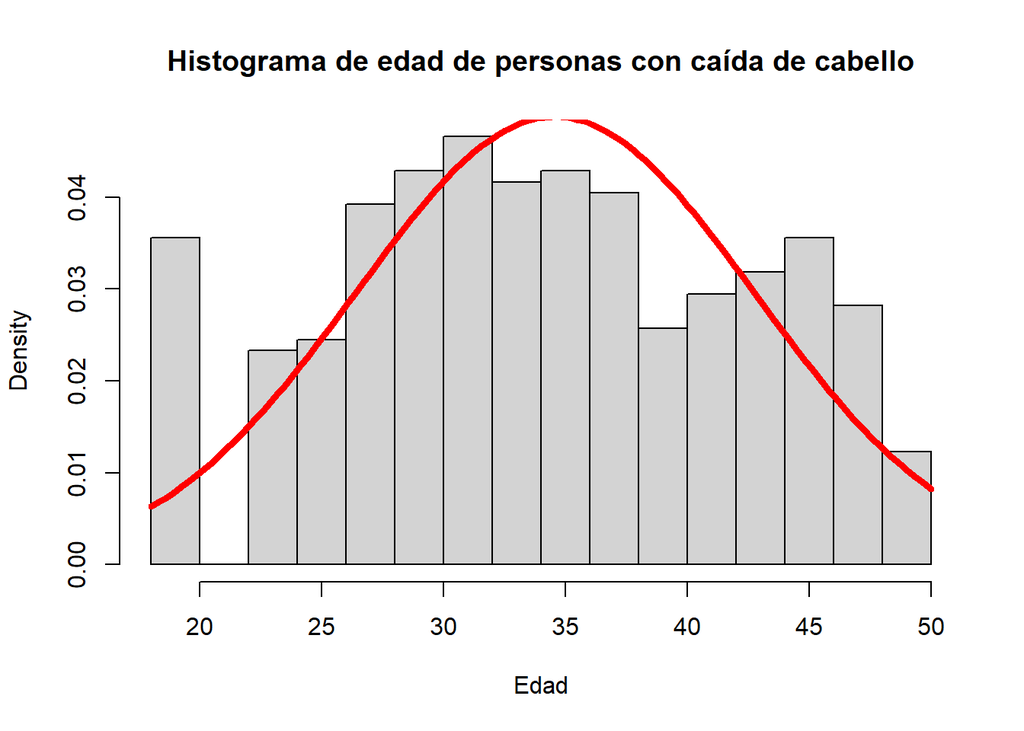

```r
# Filtramos a las personas con caida de cabello, Hair.Loss = 1
hair_age_loss1 <- subset(HairFall, Hair.Loss == 1)$Age

# Histograma
hist(hair_age_loss1, breaks = 15, prob = TRUE,
     main = "Histograma de edad de personas con caída de cabello",
     xlab = "Edad")

# Añadir curva de distribución normal teórica
x <- seq(min(hair_age_loss1), max(hair_age_loss1), length=100)
y <- dnorm(x, mean=mean(hair_age_loss1), sd=sd(hair_age_loss1))
lines(x, y, col="red", lwd=4)
```

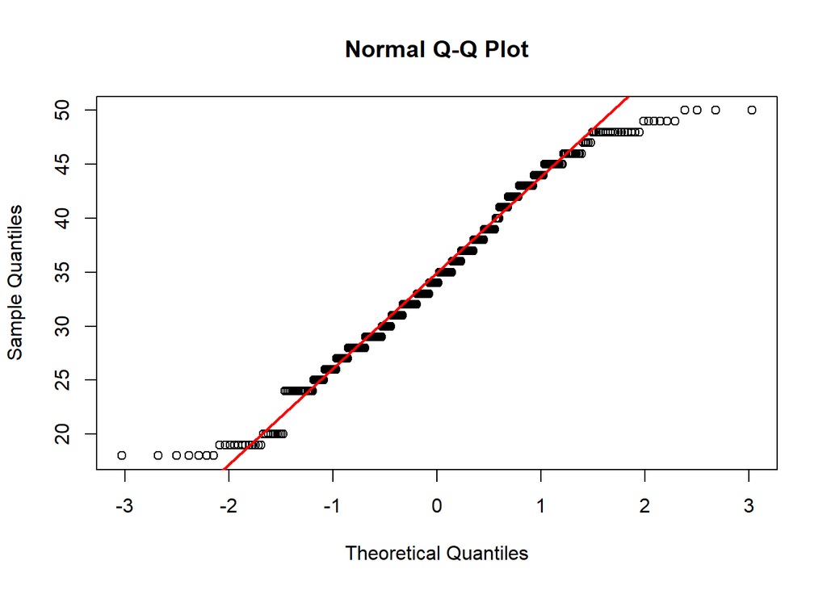

```r
# Q-Q plot para evaluar normalidad
qqnorm(hair_age_loss1)
qqline(hair_age_loss1, col = "red", lwd = 2)
```

```r
# Prueba de normalidad (Shapiro-Wilk)
shapiro.test(hair_age_loss1)
```

```
##
##  Shapiro-Wilk normality test
##
## data:  hair_age_loss1
## W = 0.97527, p-value = 2.009e-06
```

Según los resultados anteriores, y considerando que el p-value es muy bajo, rechazamos la hipótesis nula de normalidad. Esto significa que, a partir de estos datos, la edad de las personas con pérdida de cabello no sigue una distribución normal.

(0.5 puntos) 4.5. A partir del ejercicio 5 del LAB1 que trabaja con los datos Airquality del paquete *datasets*, realiza un análisis de correlación lineal sobre dos de las variables del conjunto de datos y realiza la representación gráfica que más se ajuste. (Respuesta Ej. 5 LAB1)